# Some additional notes

```r
require("ashr")
require("qvalue")
require("testthat")
set.seed(100)

# simulate n beta-hat values, nnull under the null with altmean and altsd
# being the mean and sd of beta under the alternative
simdata = function(n, nnull, altmean, altsd, betasd) {
    null = c(rep(1, nnull), rep(0, n - nnull))
    beta = c(rep(0, nnull), rnorm(n - nnull, altmean, altsd))
    betahat = rnorm(n, beta, betasd)
    return(list(null = null, beta = beta, betahat = betahat, betasd = betasd))
}

ss = simdata(10000, 8000, 0, 2, 1)

set.seed(133)
system.time((beta.ash = ash(ss$betahat, ss$betasd, prior = "uniform", randomstart = TRUE)))
```

```
##    user  system elapsed
##  11.385   0.108  11.507
```

```r
set.seed(133)
system.time((beta.ash2 = oldash(ss$betahat, ss$betasd, auto = TRUE, prior = "uniform",
    randomstart = TRUE)))
```

```
##    user  system elapsed
##   9.672   0.072   9.761
```

```r
expect_that(beta.ash$PosteriorMean, equals(beta.ash2$PosteriorMean))
expect_that(beta.ash$qvalue, equals(beta.ash2$qvalue))
expect_that(beta.ash$PositiveProb, equals(beta.ash2$PositiveProb))

system.time((beta.ash.vb.uniform = ash(ss$betahat, ss$betasd, VB = TRUE, prior = "uniform")))
```

```
##    user  system elapsed
##   38.04    0.96   39.02
```

```r
system.time((beta.ash.vb.uniform2 = oldash(ss$betahat, ss$betasd, VB = TRUE,
    auto = TRUE, prior = "uniform")))
```

```
##    user  system elapsed
##  37.451   0.717  38.190
```

```r
expect_that(beta.ash.vb.uniform$PosteriorMean, equals(beta.ash.vb.uniform2$PosteriorMean))
expect_that(beta.ash.vb.uniform$qvalue, equals(beta.ash.vb.uniform2$qvalue))
expect_that(beta.ash.vb.uniform$PositiveProb, equals(beta.ash.vb.uniform2$PositiveProb))

system.time((beta.ash.vb.null = ash(ss$betahat, ss$betasd, VB = TRUE, prior = "nullbiased")))
```

```
##    user  system elapsed
##   1.225   0.034   1.259
```

```r
system.time((beta.ash.vb.null2 = ash(ss$betahat, ss$betasd, VB = TRUE, prior = "nullbiased")))
```

```
##    user  system elapsed
##   1.134   0.049   1.184
```

```r
expect_that(beta.ash.vb.null$PosteriorMean, equals(beta.ash.vb.null2$PosteriorMean))
expect_that(beta.ash.vb.null$qvalue, equals(beta.ash.vb.null2$qvalue))
expect_that(beta.ash.vb.null$PositiveProb, equals(beta.ash.vb.null2$PositiveProb))
```

```r
require("ashr")
require("qvalue")

set.seed(100)

# Test mixVBEM
abf = rbind(c(1, 0, 0, 0), c(0, 1, 0, 0), c(0, 0, 1, 0), c(0, 0, 1, 0), c(0,
    0, 1, 0))
eps = 1e-10
abf[abf == 0] = eps  #replace 0 with small number
print(all.equal(mixVBEM(abf, c(1, 1, 1, 1))$post, c(2, 2, 4, 1)))
```

```
## [1] TRUE
```

```r
print(all.equal(mixVBEM(abf, c(1, 2, 1, 1))$post, c(2, 3, 4, 1)))
```

```
## [1] TRUE
```

```r
# simulate n beta-hat values, nnull under the null with altmean and altsd
# being the mean and sd of beta under the alternative
simdata = function(n, nnull, altmean, altsd, betasd) {
    null = c(rep(1, nnull), rep(0, n - nnull))
    beta = c(rep(0, nnull), rnorm(n - nnull, altmean, altsd))
    betahat = rnorm(n, beta, betasd)
    return(list(null = null, beta = beta, betahat = betahat, betasd = betasd))
}

ss = simdata(10000, 8000, 0, 2, 1)

system.time((beta.ash = ash(ss$betahat, ss$betasd, sigmaavec = c(0, 0.01, 0.02,
    0.04, 0.08, 0.16, 0.32, 0.64, 1.28, 2.56, 5.12, 10.24))))
```

```
## Error: unused argument (sigmaavec = c(0, 0.01, 0.02, 0.04, 0.08, 0.16,
## 0.32, 0.64, 1.28, 2.56, 5.12, 10.24))
```

```
## Timing stopped at: 0 0 0
```

```r
system.time((beta.ash.auto = ash(ss$betahat, ss$betasd)))
```

```
##    user  system elapsed
##  10.692   0.575  11.277
```

```r
system.time((beta.ash.vb.uniform = ash(ss$betahat, ss$betasd, VB = TRUE, prior = "uniform")))
```

```
##    user  system elapsed
##  32.626   2.596  35.235
```

```r
system.time((beta.ash.vb.null = ash(ss$betahat, ss$betasd, VB = TRUE, prior = NULL)))
```

```
## Error: argument is of length zero
```

```
## Timing stopped at: 0.001 0 0.001
```

```r
system.time((beta.ash.vb.null = ash(ss$betahat, ss$betasd, VB = TRUE, prior = "strongnull")))
```

```
## Error: invalid prior specification
```

```
## Timing stopped at: 0.001 0 0.001
```

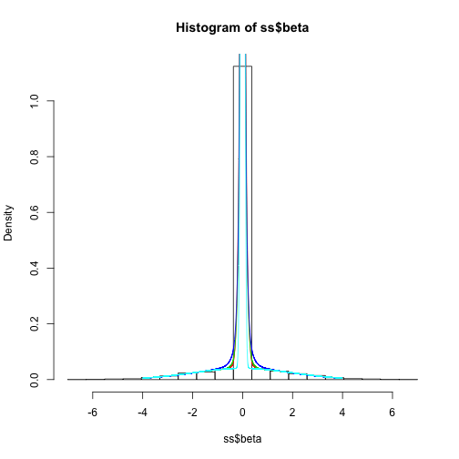

```r
hist(ss$beta, prob = TRUE, breaks = seq(floor(min(ss$beta)), ceiling(max(ss$beta)),
    length = 20))
x = seq(-4, 4, length = 10000)
lines(x, density(beta.ash, x), col = 2)
lines(x, density(beta.ash.auto, x), col = 3)
lines(x, density(beta.ash.vb.uniform, x), col = 4)
lines(x, density(beta.ash.vb.null, x), col = 5)
```

```r
summary(beta.ash)
```

```
## $pi
## [1] 3.838e-01 3.981e-01 1.720e-02 1.725e-03 3.048e-05 1.991e-01 1.617e-13
## [8] 2.220e-20 0.000e+00
##
## $mean
## [1] 0 0 0 0 0 0 0 0 0
##
## $sd
## [1]  0.06201  0.12402  0.24803  0.49606  0.99212  1.98425  3.96850  7.93700
## [9] 15.87399
##
## attr(,"row.names")
## [1] 1 2 3 4 5 6 7 8 9
## attr(,"class")
## [1] "normalmix"
## [1] -16690.5136
## [1] TRUE
```

```r
summary(beta.ash.auto)
```

```
## $pi
## [1] 4.726e-01 2.857e-01 4.251e-02 9.831e-05 1.106e-08 1.992e-01 7.772e-19
## [8] 2.220e-20 0.000e+00
##
## $mean
## [1] 0 0 0 0 0 0 0 0 0
##
## $sd
## [1]  0.06201  0.12402  0.24803  0.49606  0.99212  1.98425  3.96850  7.93700
## [9] 15.87399
##
## attr(,"row.names")
## [1] 1 2 3 4 5 6 7 8 9
## attr(,"class")
## [1] "normalmix"
## [1] -16690.49366
## [1] TRUE
```

```r
summary(beta.ash.vb.uniform)
```

```
## $pi
## [1] 0.4243582 0.2678798 0.0805104 0.0234994 0.0120815 0.1895988 0.0017039
## [8] 0.0002309 0.0001371
##
## $mean
## [1] 0 0 0 0 0 0 0 0 0
##
## $sd
## [1]  0.06201  0.12402  0.24803  0.49606  0.99212  1.98425  3.96850  7.93700
## [9] 15.87399
##
## attr(,"row.names")
## [1] 1 2 3 4 5 6 7 8 9
## attr(,"class")
## [1] "normalmix"
## [1] -29690.87569
## [1] FALSE
```

```r
summary(beta.ash.vb.null)
```

```
## $pi
## [1] 7.992e-01 1.252e-05 1.252e-05 1.252e-05 1.252e-05 2.007e-01 1.252e-05
## [8] 1.251e-05 1.251e-05
##
## $mean
## [1] 0 0 0 0 0 0 0 0 0
##
## $sd
## [1]  0.06201  0.12402  0.24803  0.49606  0.99212  1.98425  3.96850  7.93700
## [9] 15.87399
##
## attr(,"row.names")
## [1] 1 2 3 4 5 6 7 8 9
## attr(,"class")
## [1] "normalmix"
## [1] -20787.72242
## [1] TRUE
```

```r
ss = simdata(10000, 10000, 0, 2, 1)
system.time((beta.ash = ash(ss$betahat, ss$betasd)))
```

[output not shown]

```r
system.time((beta.ash.auto = ash(ss$betahat, ss$betasd)))
```

```
##    user  system elapsed
##   10.52    0.82   11.47
```

```r
system.time((beta.ash.vb.uniform = ash(ss$betahat, ss$betasd, VB = TRUE, prior = "uniform")))
```

```
##    user  system elapsed
##  29.360   2.696  32.114
```

```r
system.time((beta.ash.vb.null = ash(ss$betahat, ss$betasd, VB = TRUE, prior = NULL)))
```

```
## Error: argument is of length zero
```

```
## Timing stopped at: 0.001 0 0.001
```

```r
hist(ss$beta, prob = TRUE, breaks = seq(floor(min(ss$beta)), ceiling(max(ss$beta)),
    length = 20))
```

```
## Error: need finite 'ylim' values
```

```r
x = seq(-4, 4, length = 10000)
lines(x, density(beta.ash, x), col = 2)
lines(x, density(beta.ash.auto, x), col = 3)
lines(x, density(beta.ash.vb.uniform, x), col = 4)
lines(x, density(beta.ash.vb.null, x), col = 5)
beta.ash$fitted.f
```

```r
beta.ash.auto$fitted.f
```

```r
beta.ash.vb.uniform$fitted.f
```

```r
beta.ash.vb.null$fitted.f
```

```r
beta.ash.vb.uniform$fit$loglik
```

[output not shown]

[output cut: 541 more lines]

```r
beta.ash.vb.uniform$fit$converged
```

```
## [1] FALSE
```

```r
ss = simdata(10000, 8000, 0, 2, 1)

beta.ash = ash(ss$betahat, ss$betasd, sigmaavec = c(0, 0.01, 0.02, 0.04, 0.08,
    0.16, 0.32, 0.64, 1.28, 2.56, 5.12, 10.24))
```

```
## Error: unused argument (sigmaavec = c(0, 0.01, 0.02, 0.04, 0.08, 0.16,
## 0.32, 0.64, 1.28, 2.56, 5.12, 10.24))
```

```r
beta.ash.auto = ash(ss$betahat, ss$betasd)
# these to test the VB version
beta.ash.vb.uniform = ash(ss$betahat, ss$betasd, VB = TRUE, prior = "uniform")
beta.ash.vb.null = ash(ss$betahat, ss$betasd, VB = TRUE, prior = NULL)
```

```
## Error: argument is of length zero
```

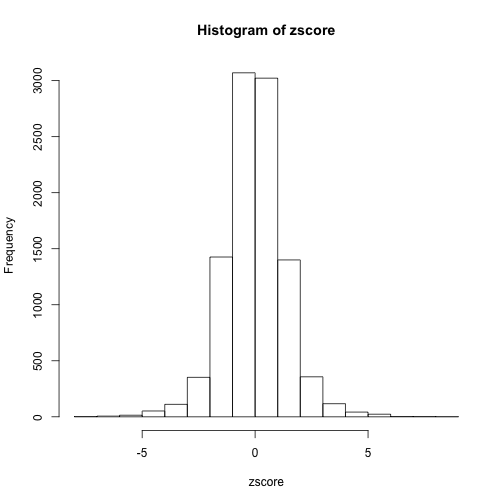

```r
beta.ash.pm = ash(ss$betahat, ss$betasd, usePointMass = TRUE)

# compute the usual zscore and corresponding p value
zscore = ss$betahat/ss$betasd

pval = pchisq(zscore^2, df = 1, lower.tail = F)
qval = qvalue(pval)
hist(zscore)
```

```r
summary(beta.ash)
```

```
## $pi
## [1] 1 0 0 0 0 0 0 0
##
## $mean
## [1] 0 0 0 0 0 0 0 0
##
## $sd
## [1] 0.0541 0.1082 0.2164 0.4328 0.8656 1.7312 3.4623 6.9247
##
## attr(,"row.names")
## [1] 1 2 3 4 5 6 7 8
## attr(,"class")
## [1] "normalmix"
## [1] -14135.45701
## [1] TRUE
```

```r
summary(beta.ash.auto)
```

```
## $pi
## [1] 2.563e-01 2.450e-01 2.052e-01 1.078e-01 3.416e-02 1.515e-01 8.656e-16
## [8] 2.220e-20 0.000e+00
##
## $mean
## [1] 0 0 0 0 0 0 0 0 0
##
## $sd
## [1]  0.0682  0.1364  0.2728  0.5456  1.0911  2.1823  4.3645  8.7290 17.4581
##
## attr(,"row.names")
## [1] 1 2 3 4 5 6 7 8 9
## attr(,"class")
## [1] "normalmix"
## [1] -16748.55712
## [1] TRUE
```

```r
summary(beta.ash.vb.uniform)
```

```
## $pi
## [1] 0.2748968 0.2532245 0.1870343 0.0843389 0.0533289 0.1460410 0.0007974
## [8] 0.0002053 0.0001328
##
## $mean
## [1] 0 0 0 0 0 0 0 0 0
##
## $sd
## [1]  0.0682  0.1364  0.2728  0.5456  1.0911  2.1823  4.3645  8.7290 17.4581
##
## attr(,"row.names")
## [1] 1 2 3 4 5 6 7 8 9
## attr(,"class")
## [1] "normalmix"
## [1] -32597.80442
## [1] FALSE
```

```r
summary(beta.ash.vb.null)
```

```
## $pi
## [1] 7.992e-01 1.252e-05 1.252e-05 1.252e-05 1.252e-05 2.007e-01 1.252e-05
## [8] 1.251e-05 1.251e-05
##
## $mean
## [1] 0 0 0 0 0 0 0 0 0
##
## $sd
## [1]  0.06201  0.12402  0.24803  0.49606  0.99212  1.98425  3.96850  7.93700
## [9] 15.87399
##
## attr(,"row.names")
## [1] 1 2 3 4 5 6 7 8 9
## attr(,"class")
## [1] "normalmix"
## [1] -20787.72242
## [1] TRUE
```

```r
summary(beta.ash.pm)
```

```
## $pi
##  [1] 1.856e-01 1.837e-01 1.781e-01 1.577e-01 1.003e-01 4.456e-02 1.501e-01
##  [8] 1.620e-13 2.220e-20 0.000e+00
##
## $mean
##  [1] 0 0 0 0 0 0 0 0 0 0
##
## $sd
##  [1]  0.0000  0.0682  0.1364  0.2728  0.5456  1.0911  2.1823  4.3645
##  [9]  8.7290 17.4581
##
## attr(,"row.names")
##  [1]  1  2  3  4  5  6  7  8  9 10
## attr(,"class")
## [1] "normalmix"
## [1] -16748.53395
## [1] TRUE
```

Plot the fitted underlying distribution on top of true values for beta

```r
hist(ss$beta, prob = TRUE, breaks = seq(-7, 7, length = 20))
```

```
## Error: some 'x' not counted; maybe 'breaks' do not span range of 'x'
```

```r
x = seq(-7, 7, length = 1000)
lines(x, density(beta.ash, x), col = 2)
```

```
## Error: plot.new has not been called yet
```

```r
plot(sort(ss$beta), (1:length(ss$beta))/length(ss$beta), main = "cdf of ss$beta, with fitted f overlaid",
    xlab = "beta", ylab = "cdf")
lines(x, cdf.ash(beta.ash, x), col = 2, lwd = 2)
lines(x, cdf.ash(beta.ash.auto, x), col = 3, lwd = 2)
lines(x, cdf.ash(beta.ash.vb.uniform, x), col = 4, lwd = 2)
lines(x, cdf.ash(beta.ash.vb.null, x), col = 5, lwd = 2)
lines(x, cdf.ash(beta.ash.pm, x), col = 6, lwd = 2)
```

[output not shown]

[for testing: compare results with point mass and without]

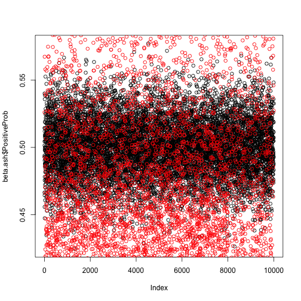

```r
plot(beta.ash$PositiveProb)
points(beta.ash.pm$PositiveProb, col = 2)
```

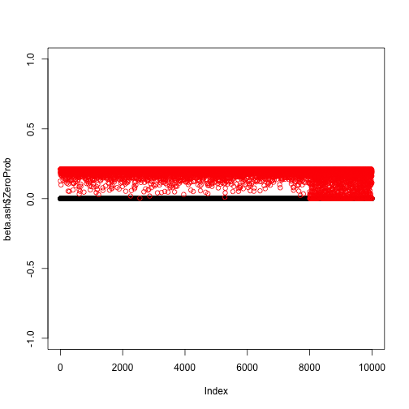

```r
plot(beta.ash$ZeroProb)
points(beta.ash.pm$ZeroProb, col = 2)
```

[for testing: compare with the results from the automatic way for selecting sigma]

```r
hist(ss$beta, prob = TRUE, breaks = seq(-7, 7, length = 20))
```

```
## Error: some 'x' not counted; maybe 'breaks' do not span range of 'x'
```

```r
x = seq(-4, 4, length = 1000)
lines(x, density(beta.ash.auto, x), col = 2)
```

```
## Error: plot.new has not been called yet
```

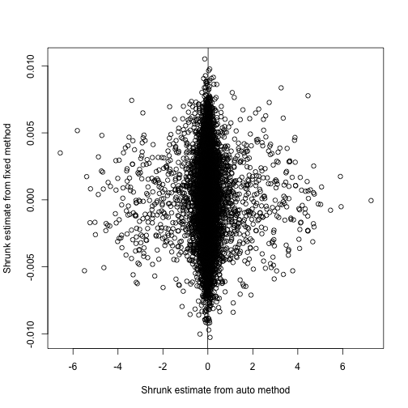

```r
plot(beta.ash.auto$PosteriorMean, beta.ash$PosteriorMean, xlab = "Shrunk estimate from auto method",
    ylab = "Shrunk estimate from fixed method")
abline(a = 0, b = 1)
```

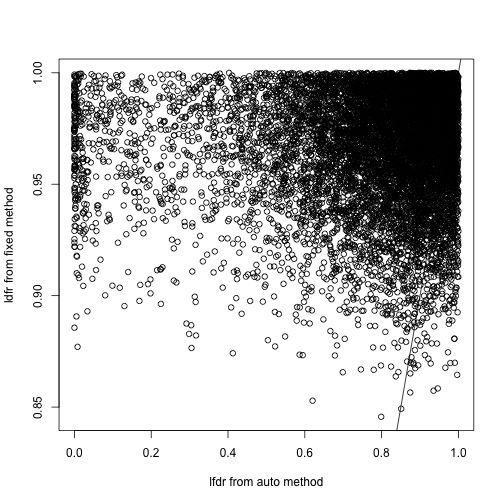

```r
plot(beta.ash.auto$localfdr, beta.ash$localfdr, xlab = "lfdr from auto method",
    ylab = "ldfr from fixed method")
abline(a = 0, b = 1)
```

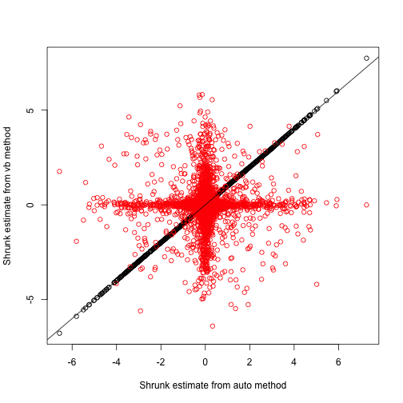

```r
plot(beta.ash.auto$PosteriorMean, beta.ash.vb.uniform$PosteriorMean, xlab = "Shrunk estimate from auto method",
    ylab = "Shrunk estimate from vb method")
points(beta.ash.auto$PosteriorMean, beta.ash.vb.null$PosteriorMean, col = 2)
abline(a = 0, b = 1)
```

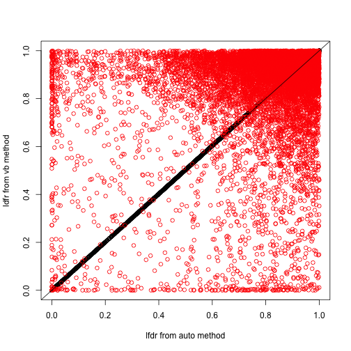

```r
plot(beta.ash.auto$localfdr, beta.ash.vb.uniform$localfdr, xlab = "lfdr from auto method",
    ylab = "ldfr from vb method")
points(beta.ash.auto$localfdr, beta.ash.vb.null$localfdr, col = 2)
abline(a = 0, b = 1)
```

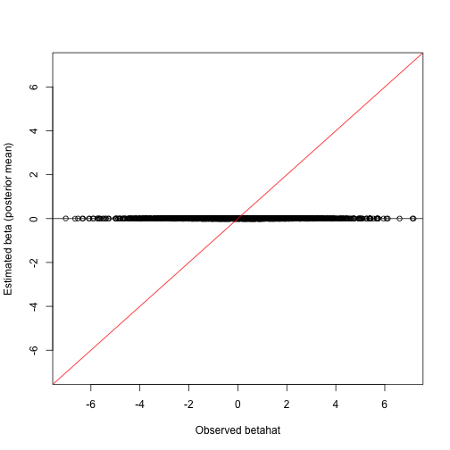

```r
plot(ss$betahat, beta.ash$PosteriorMean, xlab = "Observed betahat", ylab = "Estimated beta (posterior mean)",
    ylim = c(-7, 7), xlim = c(-7, 7))
abline(h = 0)
abline(a = 0, b = 1, col = 2)
```

### Some additional notes

#### Do we need a point mass at zero?

In some settings it is the convention to focus on testing whether \( \beta_j=0 \). However some dislike this focus, objecting that it is unlikely to be the case that \( \beta_j=0 \) exactly. For example, when comparing the average expression of a gene in human samples vs chimp samples, it might be considered unlikely that the expression is *exactly* the same in both. Whether or not \( \beta_j=0 \) is considered unlikely may depend on the context. However, in most contexts, finite data cannot distinguish between \( \beta_j=0 \) and \( \beta_j \) being very close to zero. Thus finite data cannot usually convince a skeptic that \( \beta_j \) is exactly zero, rather than just very small. In contrast it is easy to imagine data that would convince a doubter that \( \beta_j \) is truly non-zero. In this sense there is an assymetry between the inferences “\( \beta_j \) is zero” and “\( \beta_j \) is non-zero”, an assymetry that is reflected in the admonition “failure to reject the null does not imply it to be true”.

Thus any analysis that purports to distinguish between these cases must be making an assumption.

Consider two analyses of the same data, using two different “priors” \( g \) for \( \beta_j \), that effectively differ only in their assumptions about whether or not \( \beta_j \) can be exactly zero. For concreteness, consider \[ g_1(\cdot) = \pi \delta_0(\cdot) + (1-\pi) N(\cdot; 0,\sigma^2) \] and \[ g_2(\cdot) = \pi N(\cdot; 0, \epsilon^2) + (1-\pi) N(\cdot; 0, \sigma^2). \] If \( \epsilon^2 \) is sufficiently small, then these priors are “approximately the same”, and will lead to “approximately the same” posteriors and inferences in many senses. To discuss these, let \( p_j \) denote the posterior under prior \( g_j \). Then, for any given (small) \( \delta \), we will have \( p_1(|\beta_j|<\delta) \approx p_2(|\beta_j|< \delta) \). However, we will not have \( p_1(\beta_j=0) \approx p_2(\beta_j=0) \): the latter will always be zero, while the former could be appreciable.

What if, instead, we examine \( p_1(\beta_j >0) \) and \( p_2(\beta_j >0) \)? Again, these will differ. If this probability is big in the first analysis, say \( 1-\alpha \) with \( \alpha \) small, then it could be as big as \( 1-\alpha/2 \) in the second analysis. This is because if \( p_1(\beta_j>0)=1-\alpha \), then \( p_1(\beta_j=0) \) will often be close to \( \alpha \), so for small \( \epsilon \) \( p_2(\beta_j) \) will have mass \( \alpha \) near 0, of which half will be positive and half will be negative. Thus if we do an analysis without a point mass, but allow for mass near 0, then we may predict what the results would have been if we had used a point mass.

Let's try:

```r
beta.ash.pm = ash(ss$betahat, ss$betasd, usePointMass = TRUE)
print(beta.ash.pm)
```

```
## $pi
##  [1] 1.856e-01 1.837e-01 1.781e-01 1.577e-01 1.003e-01 4.456e-02 1.501e-01
##  [8] 1.620e-13 2.220e-20 0.000e+00
##
## $mean
##  [1] 0 0 0 0 0 0 0 0 0 0
##
## $sd
##  [1]  0.0000  0.0682  0.1364  0.2728  0.5456  1.0911  2.1823  4.3645
##  [9]  8.7290 17.4581
##
## attr(,"row.names")
##  [1]  1  2  3  4  5  6  7  8  9 10
## attr(,"class")
## [1] "normalmix"
```

```r
print(beta.ash.auto)
```

```
## $pi
## [1] 2.563e-01 2.450e-01 2.052e-01 1.078e-01 3.416e-02 1.515e-01 8.656e-16
## [8] 2.220e-20 0.000e+00
##
## $mean
## [1] 0 0 0 0 0 0 0 0 0
##
## $sd
## [1]  0.0682  0.1364  0.2728  0.5456  1.0911  2.1823  4.3645  8.7290 17.4581
##
## attr(,"row.names")
## [1] 1 2 3 4 5 6 7 8 9
## attr(,"class")
## [1] "normalmix"
```

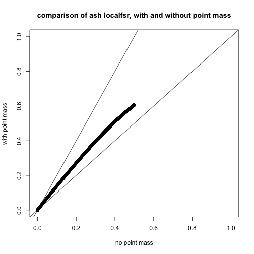

```r
plot(beta.ash.auto$localfsr, beta.ash.pm$localfsr, main = "comparison of ash localfsr, with and without point mass",
    xlab = "no point mass", ylab = "with point mass", xlim = c(0, 1), ylim = c(0,
        1))
abline(a = 0, b = 1)
abline(a = 0, b = 2)
```

Our conclusion: if we simulate data with a point mass, and we analyze it without a point mass, we may underestimate the lfsr by a factor of 2. Therefore, to be conservative, we might prefer to analyze the data allowing for the point mass, or, if analyzed without a point mass, multiply estimated false sign rates by 2. In fact the latter might be preferable: even if we analyze the data with a point mass, there is going to be some unidentifiability that means estimating the pi value on the point mass will be somewhat unreliable, and we still might underestimate the false sign rate if we rely on that estimate.  
TO THINK ABOUT: does multiplying the smaller of Pr(<0) and Pr(>0) by 2, and adding to Pr(=0) solve the problem in either case?

#### Comparison with qvalue

Here we compare ash \( q \) values with those from the qvalue package.

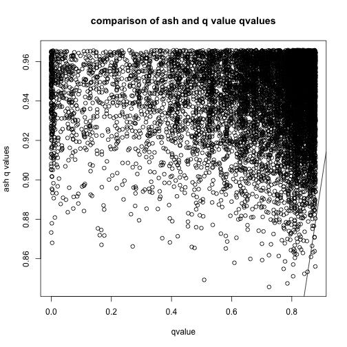

```r
plot(qval$q, beta.ash$qval, main = "comparison of ash and q value qvalues",
    xlab = "qvalue", ylab = "ash q values")
abline(a = 0, b = 1)
```

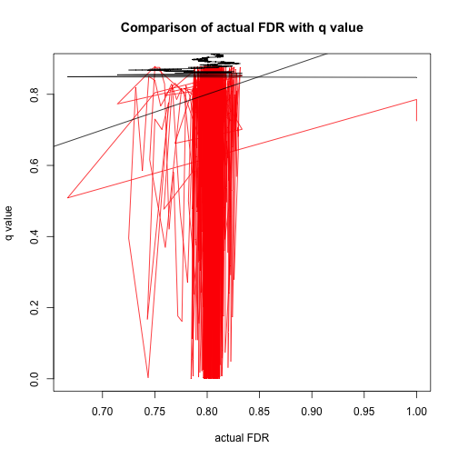

```r
o = order(beta.ash$qval)
plot(cumsum(ss$null[o])/(1:10000), qval$qval[o], col = 2, type = "l", xlab = "actual FDR",
    ylab = "q value", main = "Comparison of actual FDR with q value")
lines(cumsum(ss$null[o])/(1:10000), beta.ash$qval[o])
abline(a = 0, b = 1)
```

### Miscellaneous

code and text below here is work in progress and untidied.

Here we simulate data, effectively as in Efron, 2008, Section 7.

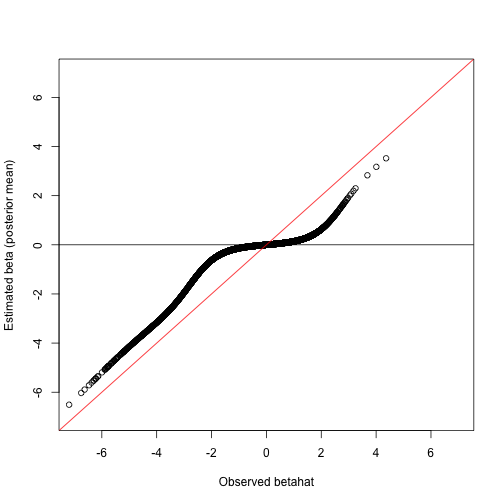

```r
truenull = c(rep(0, 1000), rep(1, 9000))
beta = c(rnorm(1000, -3, 1), rep(0, 9000))
s = rep(1, 10000)
betahat = rnorm(10000, beta, s)

beta.ash = ash(betahat, s)
# compute the usual zscore and corresponding p value
zscore = betahat/s
pval = pchisq(zscore^2, df = 1, lower.tail = F)
qval = qvalue(pval)

plot(betahat, beta.ash$PosteriorMean, xlab = "Observed betahat", ylab = "Estimated beta (posterior mean)",
    ylim = c(-7, 7), xlim = c(-7, 7))
abline(h = 0)
abline(a = 0, b = 1, col = 2)
```

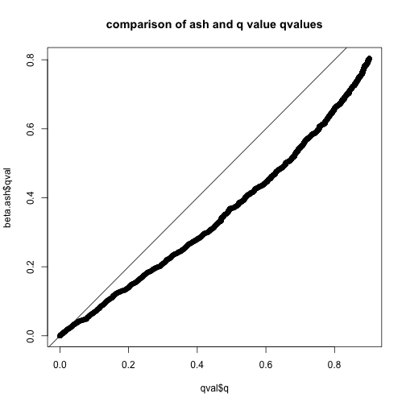

```r
plot(qval$q, beta.ash$qval, main = "comparison of ash and q value qvalues")
abline(a = 0, b = 1)
```

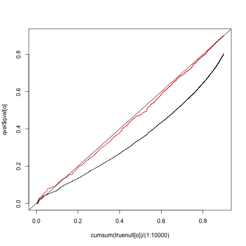

```r
o = order(beta.ash$qval)

plot(cumsum(truenull[o])/(1:10000), qval$qval[o], col = 2, type = "l")
lines(cumsum(truenull[o])/(1:10000), beta.ash$qval[o])
abline(a = 0, b = 1)
```

It seems that in this case the ash q values underestimate the FDR slightly. Possibly this is the assymetry. Try shrinking positive and negatives separately:

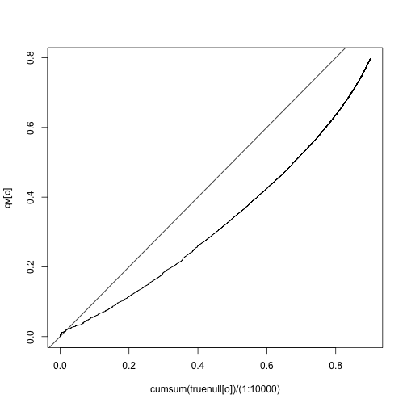

```r
pos = betahat > 0
betapos.ash = ash(betahat[pos], s[pos])
betaneg.ash = ash(betahat[!pos], s[!pos])
lfdr = rep(0, length(betahat))
lfdr[pos] = betapos.ash$localfdr
lfdr[!pos] = betaneg.ash$localfdr
qv = qval.from.localfdr(lfdr)
o = order(qv)
plot(cumsum(truenull[o])/(1:10000), qv[o], type = "l")
abline(a = 0, b = 1)
```

### Illustration of halfuniform method

I will also use this to illustrate the halfuniform method, which allows for asymmetry.

```r
truenull = c(rep(0, 2000), rep(1, 8000))
beta = c(rnorm(1000, -3, 1), rnorm(1000, -1.5, 1), rep(0, 8000))
s = rep(1, 10000)
betahat = rnorm(10000, beta, s)

beta.ash = ash(betahat, s)
beta.ash.halfu = ash(betahat, s, "halfuniform")
```

```
## [1] "Warning: Posterior SDs not yet implemented for uniform components"
```

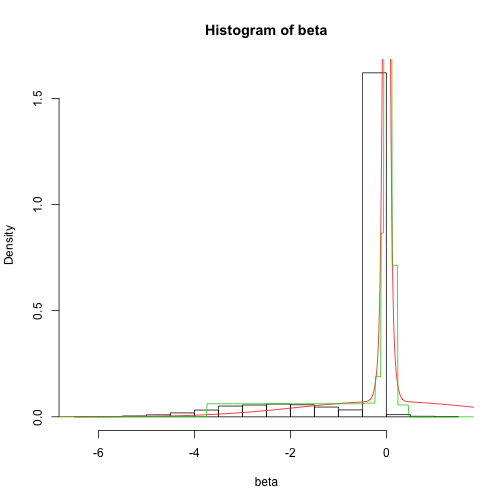

```r
hist(beta, prob = TRUE)
x = seq(-8, 4, length = 1000)
lines(x, density(beta.ash, x), col = 2)
lines(x, density(beta.ash.halfu, x), col = 3)
```

See how the use of the asymmtric uniform component does a better job capturing the underlying density. Probably clearer in the cdf plot:

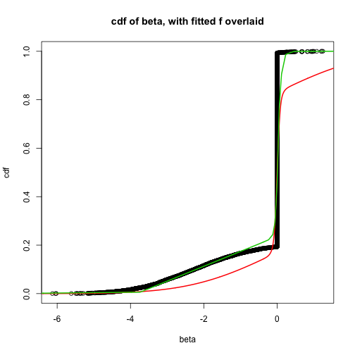

```r
plot(sort(beta), (1:length(beta))/length(beta), main = "cdf of beta, with fitted f overlaid",
    xlab = "beta", ylab = "cdf")
lines(x, cdf.ash(beta.ash, x), col = 2, lwd = 2)
lines(x, cdf.ash(beta.ash.halfu, x), col = 3, lwd = 2)
```

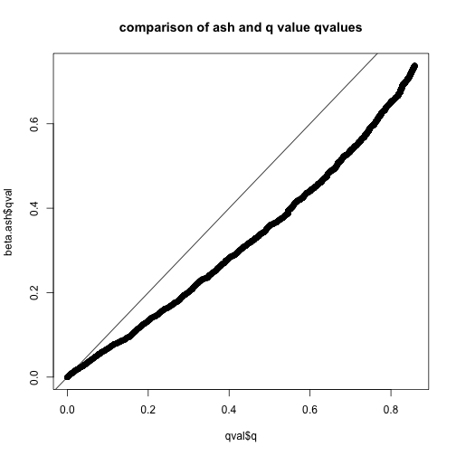

```r
# compute the usual zscore and corresponding p value
zscore = betahat/s
pval = pchisq(zscore^2, df = 1, lower.tail = F)
qval = qvalue(pval)
plot(qval$q, beta.ash$qval, main = "comparison of ash and q value qvalues")
abline(a = 0, b = 1)
```

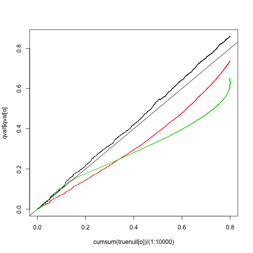

```r
o = order(qval$qval)
plot(cumsum(truenull[o])/(1:10000), qval$qval[o], col = 1, type = "l")
o = order(beta.ash$qval)
lines(cumsum(truenull[o])/(1:10000), beta.ash$qval[o], col = 2)
o2 = order(beta.ash.halfu$qval)
lines(cumsum(truenull[o2])/(1:10000), beta.ash.halfu$qval[o2], col = 3)

abline(a = 0, b = 1)
```